# A simple workflow using BOLDconnectR

Padhye SM, Ballesteros-Mejia CL,Agda TJA, Agda JRA, Ratnasingham S

2026-09-17

# A simple workflow using BOLDconnectR

## Retrieval and Analysis of BOLD Data for the Fairy Shrimp Genus *Streptocephalus* (Crustacea: Anostraca)

The following vignette presents a workflow to demonstrate the main functionality of the **BOLDconnectR** package (i.e., `search`, `fetch` and `analyze`).

Specifically, the workflow will show:

1. Searching and fetching all public *Streptocephlaus* records available on BOLD in the BCDM format.
2. Obtaining a concise summary of the downloaded data.
3. Visualizing their occurrence distribution.
4. Aligning the COI-5P sequences using `muscle` and visualizing the resulting `NJ` tree.
5. Calculating BIN richness estimates and multisite beta diversity measure between different countries.

**BOLDconnectR** can be installed either by `install.packages` (for a stable CRAN version) or the devtools package (for the development version from GitHub)

## Installation and Import

### Suggested packages

The sequence alignment and NJ tree functions require additional Bioconductor based packages to be installed and imported.

## API key

`bold.fetch()` requires an API key to retrieve the BCDM data.

#### Please note

The example dataset `test.data2` is used here for demonstrating the BOLDconnectR functionality due to the API key requirement for downloading data. The dataset represents a snapshot of public BOLD records obtained from the BOLD public data package released on June 30, 2026 (https://doi.org/10.5883/DP-BOLD_Public.30-Jun-2026). When reproducing this workflow at a later date using an API key, the query may return a different number of records because the underlying BOLD database is continuously updated.

## 1. Searching and fetching

`bold.public.search()` is used to retrieve public record IDs. `bold.full.search` can also be used instead in cases where user has private data stored. The `ids` returned using the `bold.public.search` are used in the `bold.fetch` to get the BCDM data. Here the search is also filtered based on the amplicon basepair number (`bold.fetch` *not used here as it requires an API key. A test dataset* `test.data2` *used instead*).

```r
# Search
data_ids <- bold.public.search(taxonomy = list("Streptocephalus"))
# Fetch
# streptocephalus_data <- bold.fetch(
#   get_by = "processid",
#   identifiers = data_ids$processid,
#   filt_basecount = c(500, 670)
# )
streptocephalus_data <- test.data2

DT::datatable((head(streptocephalus_data, 10)))
```

|  | processid | record_id | insdc_acs | sampleid | specimenid | taxid | short_note | identification_method | museumid | fieldid | collection_code | processid_minted_date | inst | funding_src | sex | life_stage | reproduction | habitat | collectors | site_code | specimen_linkout | collection_event_id | sampling_protocol | tissue_type | collection_date_start | collection_time | associated_taxa | associated_specimens | voucher_type | … |
| --- | --- | --- | --- | --- | --- | --- | --- | --- | --- | --- | --- | --- | --- | --- | --- | --- | --- | --- | --- | --- | --- | --- | --- | --- | --- | --- | --- | --- | --- | --- |
| 1 | GBCB0063-06 | GBCB0063-06.COI-5P | AY519833 | AY519833 | 484983 | 28909 |  |  |  |  |  |  | Mined from GenBank, NCBI |  |  |  |  |  |  |  |  |  |  |  |  |  |  |  |  | … |
| 2 | GBAAX47372-24 | GBAAX47372-24.COI-5P |  | OP536399 | 26157802 | 1841023 |  |  |  |  |  | 2024-11-22 | Mined from GenBank, NCBI |  |  |  |  |  |  |  |  |  |  |  |  |  |  |  |  | … |
| 3 | GBCB0064-06 | GBCB0064-06.COI-5P | AY519834 | AY519834 | 484984 | 28908 |  |  |  |  |  |  | Mined from GenBank, NCBI |  |  |  |  |  |  |  |  |  |  |  |  |  |  |  |  | … |
| 4 | DISA277-18 | DISA277-18.COI-5P |  | LACM:DISCO:7245 | 9517569 | 893600 | National Park Service / Santa Monica Mtns. Fund |  | LACM:DISCO:7245 |  | DISCO | 2018-11-19 | Natural History Museum of Los Angeles County |  |  |  |  | road rut | Lee Ripma | VPG68, Sta. 765, VPG68_765_Feb032016_LAR, MPBC 17676 |  | DISCO-CollectionID:RW16.325 | hand net |  | 2016-02-03 |  |  |  | Vouchered:Registered Collection | … |
| 5 | GBCB0053-06 | GBCB0053-06.COI-5P | AY519822 | AY519822 | 484973 | 28919 |  |  |  |  |  |  | Mined from GenBank, NCBI |  |  |  |  |  |  |  |  |  |  |  |  |  |  |  |  | … |
| 6 | GBCB0057-06 | GBCB0057-06.COI-5P | AY519827 | AY519827 | 484977 | 28915 |  |  |  |  |  |  | Mined from GenBank, NCBI |  |  |  |  |  |  |  |  |  |  |  |  |  |  |  |  | … |
| 7 | BCRUS015-10 | BCRUS015-10.COI-5P | HQ932705 | 09BBCRU-0015 | 1434191 | 5276 |  | Image based |  | TX090522-03 |  | 2010-04-12 | Centre for Biodiversity Genomics | iBOL:WG1.7 |  |  |  |  | K.Perez, S.McCubbin, J.Cossey, A.Borisenko |  |  |  |  |  | 2009-05-22 |  |  |  |  | … |
| 8 | GBAAX49910-24 | GBAAX49910-24.COI-5P |  | OP536382 | 26160340 | 2433286 |  |  |  |  |  | 2024-11-22 | Mined from GenBank, NCBI |  |  |  |  |  |  |  |  |  |  |  |  |  |  |  |  | … |
| 9 | GBAAX47366-24 | GBAAX47366-24.COI-5P |  | OP536400 | 26157796 | 1841023 |  |  |  |  |  | 2024-11-22 | Mined from GenBank, NCBI |  |  |  |  |  |  |  |  |  |  |  |  |  |  |  |  | … |
| 10 | LIMC412-08 | LIMC412-08.COI-5P |  | HLC-25483 | 822070 | 5276 | FAO-71 | Other sequence based approach |  | HLC-25483 |  |  | Centre for Biodiversity Genomics |  |  |  |  |  |  |  |  |  |  |  | 1998-05-19 |  |  |  |  | … |

## 2. Concise summary of the data

A concise summary of the result is generated to get an idea of what all the data contains (*Note*: The `Amplicon_lenght_range` is now between 500-670)

```r
bcdm_summary <- bold.data.summarize(
  bold_df = streptocephalus_data,
  summary_type = "concise_summary"
)
DT::datatable(bcdm_summary$concise_summary)
```

|  | Category | Value |
| --- | --- | --- |
| 1 | Total_records | 78 |
| 2 | Total_records_w_sequences | 78 |
| 3 | Unique_species | 24 |
| 4 | Unique_BINs | 27 |
| 5 | Unique_countries | 4 |
| 6 | Unique_institutes | 3 |
| 7 | Unique_identified_by | 2 |
| 8 | Unique_specimen_depositories | 4 |
| 9 | Unique_markers | COI-5P |
| 10 | Amplicon_length_range | 558-668 |

## 3. Visualizing their occurrence distribution

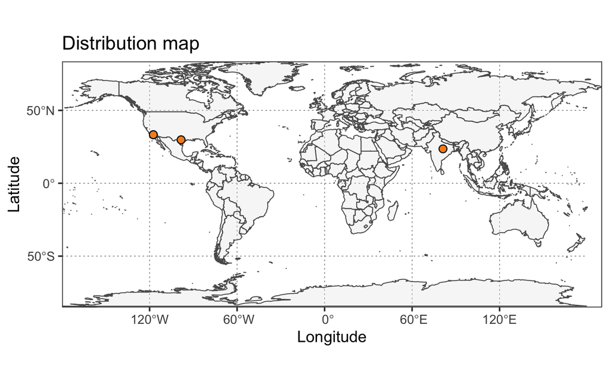

```r
map_res <- bold.analyze.map(bold_df = streptocephalus_data)
```

## 4. Alignment and visualization

### 4a. Sequence alignment

A `muscle` algorithm is run on the *Streptocephalus* sequence data to get a multiple sequence alignment. The headers for each sequence are customized so as to contain `processid` and `bin_uri` of each sequence. **Please note:** the library `Biostrings`, `muscle` and `msa` need to be imported in the R session prior to sequence alignment.

```r
seq_align <- bold.analyze.align(
  bold_df = streptocephalus_data,
  marker = "COI-5P",
  cols_for_seq_names = c("processid", "bin_uri"),
  align_method = "Muscle"
)
DT::datatable(
  seq_align[, c("aligned_seq", "msa.seq.name")],
  options = list(pageLength = 10, scrollX = TRUE)
)
```

|  | aligned_seq | msa.seq.name |
| --- | --- | --- |
| 1 | ------------------------------------------------TTTATTTTTGGTGCTTGATCAGGAATAGTCGGTACCTCCCTTAGACTCCTTATTCGTGCTGAATTAGGCCAACCTGGATCTCTATTAGGGGATGAACAACTTTACAATGTGATTGTAACGGCTCACGCCTTTATTATGATTTTCTTCATGGT… | GBCB0063-06\|BOLD:AAJ4695 |
| 2 | --------------------------------------TACTTTATATTTTATCTTTGGTGCTTGATCAGGCATGGTCGGAACTTCATTAAGTTTATTAATTCGAGCTGAACTAGGACAACCTGGATCTTTGCTAGGAGATGAACAACTTTATAATGTAATTGTAACTGCCCATGCTTTTATTATGATTTTCTTCATAGT… | GBAAX47372-24\|BOLD:AGK2589 |
| 3 | ---------------------------------------------TATATTATTTTNGGTGCTTGGTCAGGGATAGTTGGGACTTCCCTAAGTATATTAATTCGAGCTGAACTTGGTCAACCAGGTTCCTTACTGGGTGATGAACAACTCTATAATGTAATTGTTACAGCCCATGCTTTTATTATGATTTTCTTCATAGT… | GBCB0064-06\|BOLD:AAJ4696 |
| 4 | --------------------------------CATTGGTACCCTATATTTTATTTTTGGTGCTTGATCAGGAATAGTAGGGACCTCGCTTAGTATATTAATTCGAGCAGAACTCGGCCAACCTGGCTCTTTATTAGGAGATGAGCAGTTATATAATGTAATTGTTACAGCCCACGCTTTTATTATAATTTTCTTTATAGT… | DISA277-18\|BOLD:ADP5613 |
| 5 | ---------------------------------------------TATTTTATTTTTGGNGCTTGATCTGGAATGGTCGGGACCTCTCTTAGTCTATTAATTCGAGCCGAACTCGGGCAACCAGGTTCTTTATTAGGGGATGAACAATTATATAATGTAATCGTTACTGCCCACGCCTTTATCATAATTTTCTTTATAGT… | GBCB0053-06\|BOLD:AAJ4250 |
| 6 | ---------------------------------------------TATTTTATTTTTGGAGCTTGGTCTGGAATAGTTGGAACTTCCCTTAGAATACTTATTCGAGCTGAGTTAGGTCAGCCTGGATCTTTATTAGGAGACGAACAATTATATAATGTAATTGTAACAGCTCATGCTTTTATCATAATTTTCTTTATGGT… | GBCB0057-06\|BOLD:AAJ4447 |
| 7 | --------------------------------------AACTTTATATTTTATCTTTGGGGCCTGATCCGGAATAATCGGGACTTCTCTTAGTATACTGATTCGAGCAGAACTTGGTCAACCAGGTTCATTACTAGGGGACGAGCAACTGTACAATGTGATTGTTACAGCTCATGCTTTTATTATAATTTTCTTCATAGT… | BCRUS015-10\|BOLD:AAL8188 |
| 8 | --------------------------------------TACTTTATATTTCATTTTTGGTGCTTGATCAGGTATGGTTGGAACCTCATTGAGTTTACTAATTCGAGCTGAGTTAGGTCAGCCCGGATCTTTGTTAGGAGATGAGCAGCTGTATAATGTAATTGTAACAGCTCATGCTTTTATTATAATTTTCTTTATAGT… | GBAAX49910-24\|BOLD:AGK2588 |
| 9 | --------------------------------------TACTTTATATTTTATCTTTGGTGCTTGATCAGGCATGGTCGGAACTTCATTAAGTTTATTAATTCGAGCTGAACTAGGACAACCTGGATCTTTGCTAGGAGATGAACAACTTTATAATGTAATTGTAACTGCCCATGCTTTTATTATGATTTTCTTCATAGT… | GBAAX47366-24\|BOLD:AGK2589 |
| 10 | --------------------------------------AACTTTATATTTTATCTTTGGTGCTTGATCAGGAATAGTTGGGACTTCTCTTAGAATACGTATTCGTGCTGAGTTAGGTCAACCTGGTTCTTTACTGGAAGATGAGCAGTTGTACAATGTAATTGTTACAGCTCATGCCTTTATTATGATTTTCTTTATAGT… | LIMC412-08\|BOLD:AAP2665 |

[output cut: 68 more lines]

### 4b. Neighbor Joining Tree

The aligned sequences are then visualized via Neighbor Joining Tree. The output from `bold.analyze.align` is directly used for the visualization. **Please note:** the library `Biostrings`, `muscle` and `msa` need to be imported in the R session prior to sequence alignment

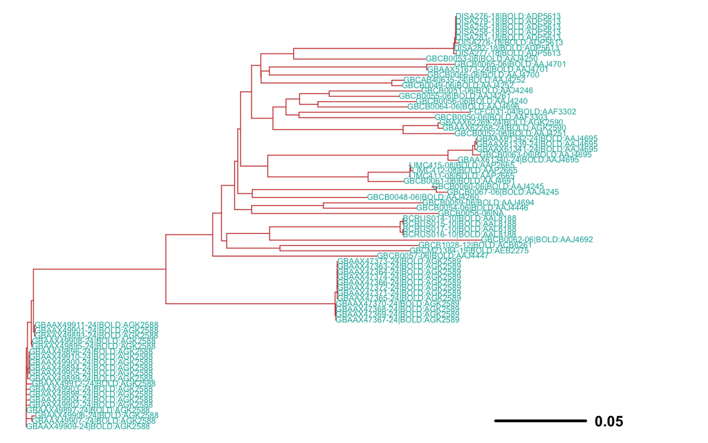

```r
seq_tree <- bold.analyze.tree(
  bold_df = seq_align,
  dist_model = "K80",
  clus_method = "nj",
  tree_plot = TRUE,
  tree_plot_type = "p",
  save_dist_mat = TRUE,
  pairwise.deletion = TRUE
)
```

```r
seq_tree$base_freq
```

```
#>         a         c         g         t
#> 0.2436683 0.2062330 0.1878957 0.3622029
```

## 5. Calculating BIN richness estimates and multisite beta diversity measure between different countries

### 5a. BIN richness

```r
diversity_res <- bold.analyze.diversity(
  bold_df = streptocephalus_data,
  taxon_rank = "species",
  site_type = "locations",
  location_type = "country.ocean",
  diversity_profile = "richness"
)
```

[output not shown]

```r
DT::datatable(diversity_res$richness)
```

|  | Sampl | Ind | Obs | S1 | S2 | Q1 | Q2 | Jack1ab | Jack1abP | Jack1in | Jack1inP | Jack2ab | Jack2abP | Jack2in | Jack2inP | Chao1 | Chao1P | Chao2 | Chao2P | ACE | ACEP | ICE | ICEP |
| --- | --- | --- | --- | --- | --- | --- | --- | --- | --- | --- | --- | --- | --- | --- | --- | --- | --- | --- | --- | --- | --- | --- | --- |
| 1 | 1 | 16.42 | 2.77 | 0.58 | 0.48 | 2.77 | 0 | 3.35 | 3.61 | 2.77 | 5.54 | 3.45 | 3.74 | 8.31 | 16.62 | 2.92 | 3.12 | 7.44 | 14.88 | 3.41 | 3.68 |  |  |
| 2 | 2 | 30.78 | 5.12 | 1.1 | 0.98 | 4.95 | 0.17 | 6.22 | 6.6 | 7.6 | 14.87 | 6.34 | 6.75 | 7.6 | 14.87 | 5.37 | 5.69 | 18.84 | 37.42 | 5.96 | 6.32 |  |  |
| 3 | 3 | 44.44 | 7.26 | 1.6 | 1.53 | 6.79 | 0.47 | 8.86 | 9.34 | 11.79 | 22.29 | 8.93 | 9.43 | 13.97 | 26.47 | 7.57 | 7.98 | 27.11 | 52.67 | 8.39 | 8.84 |  |  |
| 4 | 4 | 57 | 9 | 2 | 2 | 8 | 1 | 11 | 11.54 | 15 | 26.85 | 11 | 11.54 | 18.67 | 33.42 | 9.33 | 9.79 | 23 | 41.17 | 10.58 | 11.1 | 53 | 94.88 |

### 5b. Beta diversity

```r
beta_diversity_res <- bold.analyze.diversity(
  bold_df = streptocephalus_data,
  taxon_rank = "species",
  site_type = "locations",
  location_type = "country.ocean",
  diversity_profile = "beta",
  beta_index = "jaccard"
)

beta_diversity_res$total.beta
```

```
#>               Australia India United States
#> India               1.0
#> United States       0.5   1.0
#> Unrecoverable       1.0   1.0           1.0
```

## Export data

Data can also be exported as a FASTA file, a multiple sequence alignment file (in FASTA format) or customized datasets of BCDM based on certain presets (e.g.,preset = taxonomy will export only taxonomy based information from all the BCDM data)

```r
bold.export(
  bold_df = streptocephalus_data,
  export_type = "fas",
  cols_for_fas_names = c("bin_uri", "genus", "species"),
  export = "~/Desktop/boldconnectr_sequences.fas"
)
```

## Additional notes

In addition, several analysis functions return commonly used R data structures as part of their outputs, including an `occurrence matrix`, `sf` object, `DNABin` object containing unaligned sequences, and a `phylo` object generated from aligned sequences. These outputs can be readily integrated into workflows from other R packages for downstream analyses (e.g., using an occurrence matrix for ecological or biodiversity analyses with packages such as `vegan` and `betapart`).

For more/detailed information, please visit (https://github.com/boldsystems-central/BOLDconnectR) or use the `help` function in R.